# Terrorist Attack Analysis in Afghanistan 2002 - 2017

Christopher Cahill

December 2, 2018

# Abstract

This report was created to analyze terrorist attacks in Afghanistan starting in 2002 after United States involvement to remove the Taliban from power and hurt Al-Qaeda cells operating in the country. What began as a simple task with the military strength of the United States and its NATO allies lingered on as a growing insurgency flourished in Afghanistan. In examining terrorist attacks in the country for fifteen years, it was clear that the Taliban is more active than ever. An approach to examining the attacks in a seasonal effect also highlights how there are spikes of insurgent attacks in the summer months. While this report is exploratory in nature, it opens ideas for future studies.

# The Data

# Attacks by Terrorist Groups

In examining the terrorist attacks in Afghanistan, it was important to find the total attempted and successful attacks for each of the 27 groups to have attempted terrorist attacks during the given timeframe. Analysis was completed in R and the code chunk is provided below.

The first task was to only include relevant variables. Of the 135 variables in the original dataset, many were not needed, such as weapon details. It was also important to recode some of the days as some exact dates were unknown and left as 0 for the numerical day. For the analysis in this report, only month and year matter, but a day of zero could not be read in a date format, so all cases were changed from 0 to 1. These string were then combined to create full dates.

```r
attacks_TS<-select(attacks_AF,iyear,imonth,iday,provstate,city,gname,success)
attacks_TS$attempts<-rep(1,nrow(attacks_TS))
for(i in 1:nrow(attacks_TS)){
  if(attacks_TS$iday[i]==0){
    attacks_TS$iday[i]<-1
  }else{
    attacks_TS$iday[i]<-attacks_TS$iday[i]
  }
}
attacks_TS$date<-as.Date(paste(attacks_TS$iyear,attacks_TS$imonth,attacks_TS$iday,
                               sep='/'),'%Y/%m/%d')
attacks_TS$date<-substr(attacks_TS$date,1,7)
```

Now that dates were created for years and month, the data was aggregated over group name and date. A dataframe was created with columns being the terrorist groups and the rows being the dates. The inital dataframe was full of zeros and was then filled with total attempts and successes for each group.

Specifically, the original format of the data, shown below:

[output not shown]

|  | iyear | imonth | iday | provstate | city | gname | success | attempts |
| --- | --- | --- | --- | --- | --- | --- | --- | --- |
| 73566 | 2002 | 1 | 1 | Kabul | Kabul | Unknown | 1 | 1 |
| 73656 | 2002 | 1 | 17 | Kabul | Kabul | Unknown | 1 | 1 |
| 73951 | 2002 | 4 | 8 | Nangarhar | Jalalabad | Al-Qaida | 0 | 1 |
| 73963 | 2002 | 4 | 12 | Kabul | Kabul | Unknown | 0 | 1 |
| 73972 | 2002 | 4 | 13 | Unknown | Unknown | Taliban | 0 | 1 |
| 73973 | 2002 | 4 | 13 | Khost | Khost | Unknown | 1 | 1 |

Was reformated to what is shown below. Only the first few columns are shown, but there were a total of 28 for each of the data frames for successful and attempted attacks.

[output not shown]

| month | Unknown | Al-Qaida | Taliban | Hizb-I-Islami | Anti-United States extremists | Saif-ul-Muslimeen |
| --- | --- | --- | --- | --- | --- | --- |
| 2002-01 | 2 | 0 | 0 | 0 | 0 | 0 |
| 2002-02 | 0 | 0 | 0 | 0 | 0 | 0 |
| 2002-03 | 0 | 0 | 0 | 0 | 0 | 0 |
| 2002-04 | 1 | 0 | 0 | 0 | 0 | 0 |
| 2002-05 | 2 | 0 | 1 | 0 | 0 | 0 |
| 2002-06 | 0 | 1 | 0 | 0 | 0 | 0 |

After reorganizing the data into groups, the totals can be plotted. The plot below shows the timeline of all years from 2002 through 2017. What is alarming is the seemingly increased attacks, especially by Taliban forces.

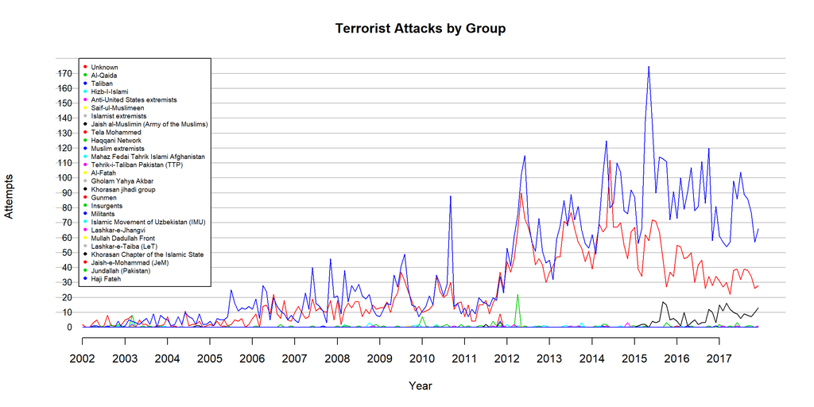

The second largest group is Unknown, but despite a spike in 2013-2014, attacks by Unknown groups have gone down. Whether this is because of smaller insurgencies being put down or the attackers being identified better is not known.